# Decision Trees with Package `rpart`

Package `rpart` is used to build a decision tree on the bodyfat data . Function rpart() is used to build a decision tree, and the tree with the minimum prediction error is selected. After that, it is applied to new data to make prediction with function predict().

mboost package - Model-Based Boosting

bodyfat - For 71 healthy female subjects, body fat measurements and several anthropometric measurements are available for predictive modelling of body fat.

```r
#install.packages('mboost', dep=T)
library(mboost)
data("bodyfat", package = "TH.data")
```

```r
dim(bodyfat)
```

```
## [1] 71 10
```

```r
attributes(bodyfat)
```

```
## $names
##  [1] "age"          "DEXfat"       "waistcirc"    "hipcirc"
##  [5] "elbowbreadth" "kneebreadth"  "anthro3a"     "anthro3b"
##  [9] "anthro3c"     "anthro4"
##
## $row.names
##  [1] "47"  "48"  "49"  "50"  "51"  "52"  "53"  "54"  "55"  "56"  "57"
## [12] "58"  "59"  "60"  "61"  "62"  "63"  "64"  "65"  "66"  "67"  "68"
## [23] "69"  "70"  "71"  "72"  "73"  "74"  "75"  "76"  "77"  "78"  "79"
## [34] "80"  "81"  "82"  "83"  "84"  "85"  "86"  "87"  "88"  "89"  "90"
## [45] "91"  "92"  "93"  "94"  "95"  "96"  "97"  "98"  "99"  "100" "101"
## [56] "102" "103" "104" "105" "106" "107" "108" "109" "110" "111" "112"
## [67] "113" "114" "115" "116" "117"
##
## $class
## [1] "data.frame"
```

```r
bodyfat[1:5,]
```

```
##    age DEXfat waistcirc hipcirc elbowbreadth kneebreadth anthro3a anthro3b
## 47  57  41.68     100.0   112.0          7.1         9.4     4.42     4.95
## 48  65  43.29      99.5   116.5          6.5         8.9     4.63     5.01
## 49  59  35.41      96.0   108.5          6.2         8.9     4.12     4.74
## 50  58  22.79      72.0    96.5          6.1         9.2     4.03     4.48
## 51  60  36.42      89.5   100.5          7.1        10.0     4.24     4.68
##    anthro3c anthro4
## 47     4.50    6.13
## 48     4.48    6.37
## 49     4.60    5.82
## 50     3.91    5.66
## 51     4.15    5.91
```

Split the data into training and test datasets.

Build a decision tree on the training dataset.

```r
set.seed(1234)
ind  <- sample(2,nrow(bodyfat), replace=T, prob=c(0.7, 0.3))
bodyfat.train  <- bodyfat[ind == 1,]
bodyfat.test  <- bodyfat[ind == 2,]
```

Train a decision tree.

rpart - Recursive Partitioning and Regression Trees

`Recursive partitioning` is a statistical method for multivariable analysis. Recursive partitioning creates a decision tree that strives to correctly classify members of the population by splitting it into sub-populations based on several dichotomous (different) independent variables. The process is termed recursive because each sub-population may in turn be split an indefinite number of times until the splitting process terminates after a particular stopping criterion is reached.

Linear regression is a **global model**, where there is a single predictive formula holding over the entire data-space. When the data has lots of features which interact in complicated, nonlinear ways, assembling a single global model can be very difficult, and hopelessly confusing when you do succeed. An alternative approach to nonlinear regression is to sub-divide, or partition, the space into smaller regions, where the interactions are more manageable. We then partition the sub-divisions again — this is called **recursive partitioning** — until finally we get to chunks of the space which are so tame that we can fit simple models to them. The **global model** thus has two parts: one is just the recursive partition, the other is a simple model for each cell of the partition.

Prediction trees use the tree to represent the recursive partition. Each of the **terminal nodes**, or **leaves**, of the tree represents a cell of the partition, and has attached to it a simple model which applies in that cell only.

> control - a list of options that control details of the rpart algorithm `??rpart.control` minsplit - the minimum number of observations that must exist in a node in order for a split to be attempted.

```r
library(rpart)
myFormula  <- DEXfat ~ age + waistcirc + waistcirc + elbowbreadth + kneebreadth
bodyfat_rpart <- rpart(myFormula, data = bodyfat.train,
                       control = rpart.control(minsplit = 10))
```

```r
attributes(bodyfat_rpart)
```

```
## $names
##  [1] "frame"               "where"               "call"
##  [4] "terms"               "cptable"             "method"
##  [7] "parms"               "control"             "functions"
## [10] "numresp"             "splits"              "variable.importance"
## [13] "y"                   "ordered"
##
## $xlevels
## named list()
##
## $class
## [1] "rpart"
```

```r
##??rpart.object
```

`cptable` - a matrix of information on the optimal prunings based on a complexity parameter.

```r
print(bodyfat_rpart$cptable)
```

```
##           CP nsplit rel error    xerror       xstd
## 1 0.67272638      0 1.0000000 1.0194546 0.18724382
## 2 0.09390665      1 0.3272736 0.4099840 0.10549017
## 3 0.05462431      2 0.2333670 0.4093311 0.09312748
## 4 0.02459470      3 0.1787427 0.3588495 0.08701886
## 5 0.01808532      4 0.1541480 0.3484629 0.08758464
## 6 0.01000000      5 0.1360626 0.3088167 0.07586534
```

```r
print(bodyfat_rpart)
```

```
## n= 56
##
## node), split, n, deviance, yval
##       * denotes terminal node
##
##  1) root 56 7265.02900 30.94589
##    2) waistcirc< 88.4 31  960.53810 22.55645
##      4) waistcirc< 71.5 7   67.44809 15.93143 *
##      5) waistcirc>=71.5 24  496.24290 24.48875
##       10) kneebreadth< 9.35 20  263.90930 23.26850 *
##       11) kneebreadth>=9.35 4   53.65240 30.59000 *
##    3) waistcirc>=88.4 25 1417.11400 41.34880
##      6) waistcirc< 104.75 18  330.57920 38.09111
##       12) elbowbreadth< 6.35 7   80.57217 34.70429 *
##       13) elbowbreadth>=6.35 11  118.61670 40.24636 *
##      7) waistcirc>=104.75 7  404.30040 49.72571 *
```

## Plot the tree

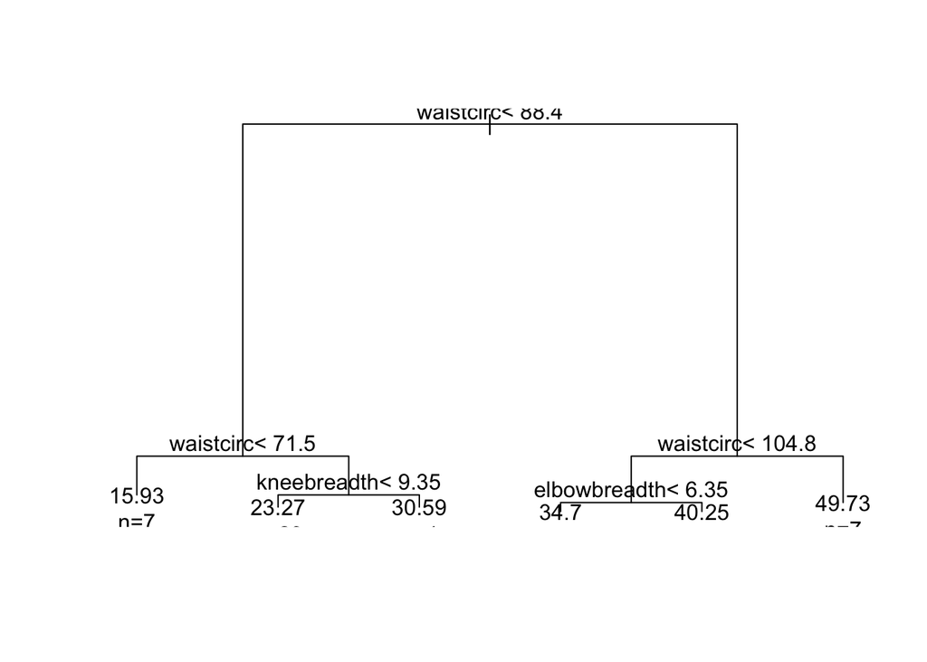

```r
plot(bodyfat_rpart)
text(bodyfat_rpart, use.n=T)
```

Select the tree with minimum prediction error

```r
opt  <- which.min(bodyfat_rpart$cptable[,"xerror"])
cp  <- bodyfat_rpart$cptable[opt, "CP"]
bodyfat_prune  <- prune(bodyfat_rpart, cp = cp)
print(bodyfat_prune)
```

```
## n= 56
##
## node), split, n, deviance, yval
##       * denotes terminal node
##
##  1) root 56 7265.02900 30.94589
##    2) waistcirc< 88.4 31  960.53810 22.55645
##      4) waistcirc< 71.5 7   67.44809 15.93143 *
##      5) waistcirc>=71.5 24  496.24290 24.48875
##       10) kneebreadth< 9.35 20  263.90930 23.26850 *
##       11) kneebreadth>=9.35 4   53.65240 30.59000 *
##    3) waistcirc>=88.4 25 1417.11400 41.34880
##      6) waistcirc< 104.75 18  330.57920 38.09111
##       12) elbowbreadth< 6.35 7   80.57217 34.70429 *
##       13) elbowbreadth>=6.35 11  118.61670 40.24636 *
##      7) waistcirc>=104.75 7  404.30040 49.72571 *
```

```r
#print(bodyfat_rpart)
```

?prune - Cost-complexity Pruning of an Rpart Object - Determines a nested sequence of subtrees of the supplied `rpart` object by recursively snipping off the least important splits, based on the complexity parameter (cp)

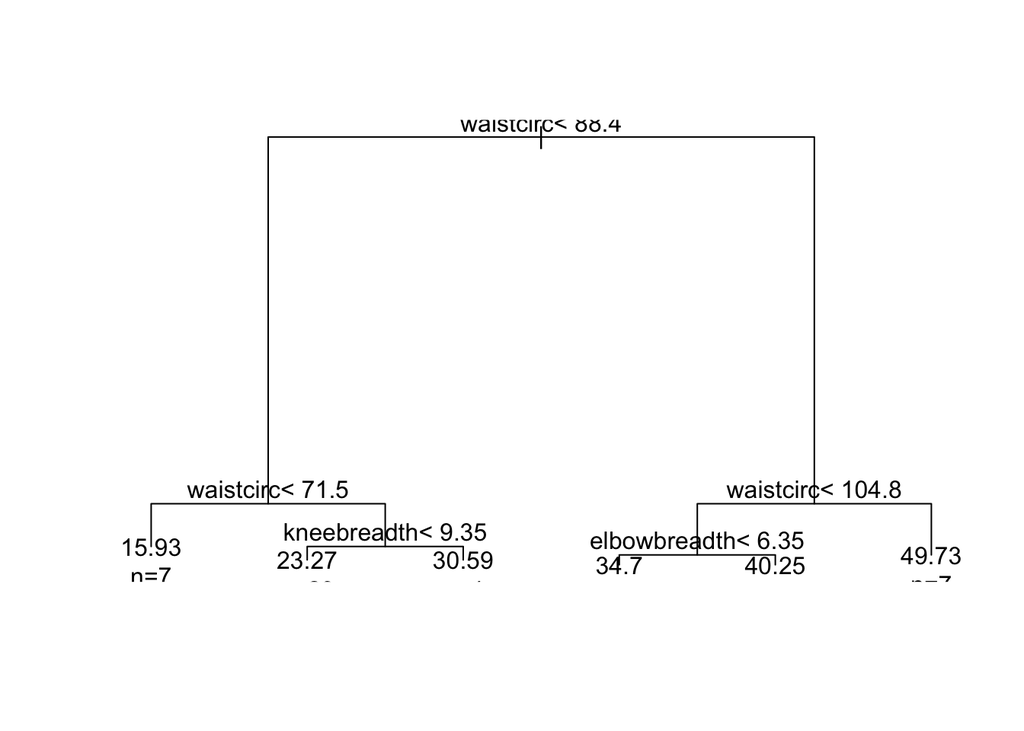

```r
plot(bodyfat_prune)
text(bodyfat_prune, use.n = T)
```

Use the selected tree to make `prediciton` and compared with actual labels.

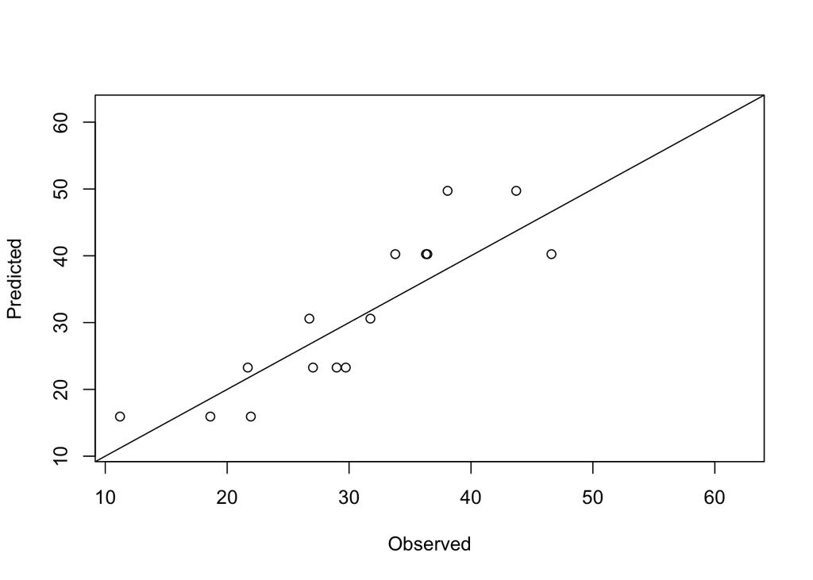

```r
DEXfat_pred  <- predict(bodyfat_prune, newdata= bodyfat.test)
xlim  <- range(bodyfat$DEXfat)
plot(DEXfat_pred ~ DEXfat, data = bodyfat.test, xlab="Observed",
     ylab="Predicted", ylim=xlim, xlim=xlim)
abline(a=0, b=1)
```

References - - https://en.wikipedia.org/wiki/Recursive_partitioning - http://www.stat.cmu.edu/~cshalizi/350-2006/lecture-10.pdf